# 🎬 Movie Recommendation System using Machine Learning

### DATA 607 - Statistical and Machine Learning

### Submitted by:

- Marcelino Rodriguez
- Rajvir Kaur
- Nyadual Makuach
- Yaowei Sun

# **Introduction**

This project aims to develop a movie recommendation system using machine learning techniques.It is designed designed to predict user preferences based on their past behavior. These systems analyze viewing history, user ratings, and interactions to suggest personalized movie recommendations, enhancing user engagement and satisfaction.

It explores multiple recommendation approaches, including content-based filtering, collaborative filtering, popularity-based methods, and a hybrid model that combines them. The system is designed to deliver personalized, accurate, and meaningful movie suggestions by analyzing user preferences and movie characteristics.

Exploratory Data Analysis (EDA) is conducted to uncover insights such as the distribution of ratings, the most common movie genres, the most expensive and popular movies, and the relationship between budget and revenue. These visual analyses provided critical understanding of user preferences and movie trends, forming the foundation for building effective models.

The project implements three recommendation strategies:

**Content-Based Filtering**:

- Recommends movies similar in genre or description to what a user already likes.

**Collaborative Filtering (SVD)**:

- Learns hidden user-item relationships from past ratings and predicts how much a user would like unseen movies.

**Hybrid Model**:

- Combines both content and collaborative features for more robust and personalized recommendations.

Each model is evaluated using metrics such as RMSE, MAE, Accuracy, Precision, Recall, and F1 Score to measure performance. The project also addresses limitations like the cold-start problem, proposing hybrid strategies to improve coverage and accuracy. With intuitive Streamlit web interfaces, users can interactively explore recommendations and understand how each model works behind the scenes.

# **Dataset Overview**

The dataset used for this movie recommendation system project is sourced from Kaggle, specifically from the MovieLens dataset. It consists of two main files: **`movies_data.csv`** and **`ratings_small.csv`**.

The final dataset is clean, feature-rich, and ideal for developing and evaluating multiple recommendation models, including **popularity-based**, **content-based**, **collaborative filtering (SVD)**, and **hybrid approaches**. It also supports extensive exploratory data analysis to reveal insights such as genre trends, rating distributions, and budget versus revenue patterns.

# **Research Questions and Exploratory Analysis**

#### **Exploratory Data Analysis (EDA)**

1. What is the distribution of movie ratings?
2. What are the most common genres in the dataset?
3. What are the top 10 most popular and most highly rated movies (with sufficient votes)?
4. What is the relationship between budget and revenue?
5. How many movies are released each year?

#### **Research Questions**

1. **How effective is a Popularity-Based Recommendation System** in identifying the top 10 most relevant movies using vote average, vote count, and popularity score as key indicators?
2. **To what extent can movie metadata** such as genres and overview be leveraged to generate accurate and relevant content-based recommendations using machine learning techniques?
3. **How effectively can collaborative filtering algorithms** predict user preferences by analyzing patterns in historical user ratings?
4. **What impact does combining content-based and collaborative filtering** approaches have on the accuracy and quality of movie recommendations?

## **Ealuation Matrices for comparing Model Performance**

##### Accuracy

- What it means: How often the model's predictions (good/bad movie) match the actual rating.

##### Precision

- What it means: Of all the movies predicted as "liked", how many were actually liked?

##### Recall

- What it means: Of all the movies the user actually liked, how many did the model correctly identify?

##### F1 Score

- What it means: The harmonic mean of precision and recall — balances both.

##### RMSE (Root Mean Squared Error)

- What it means: Measures how far the predicted ratings are from the actual ratings — penalizes larger errors more heavily.

##### MAE (Mean Absolute Error)

- What it means: The average of how far off each prediction is from the actual rating.

```python
import pandas as pd


movies_path = "movies_data.csv"
ratings_path = "ratings_small.csv"

movies_df = pd.read_csv(movies_path)
ratings_df = pd.read_csv(ratings_path)


movies_df.head(5)
```

|  | id | budget | genres | overview | popularity | release_date | revenue | title | vote_average | vote_count |
| --- | --- | --- | --- | --- | --- | --- | --- | --- | --- | --- |
| 0 | 862 | 30000000 | [{'id': 16, 'name': 'Animation'}, {'id': 35, '... | Led by Woody, Andy's toys live happily in his ... | 21.946943 | 1995-10-30 | 373554033.0 | Toy Story | 7.7 | 5415.0 |
| 1 | 8844 | 65000000 | [{'id': 12, 'name': 'Adventure'}, {'id': 14, '... | When siblings Judy and Peter discover an encha... | 17.015539 | 1995-12-15 | 262797249.0 | Jumanji | 6.9 | 2413.0 |
| 2 | 15602 | 0 | [{'id': 10749, 'name': 'Romance'}, {'id': 35, ... | A family wedding reignites the ancient feud be... | 11.7129 | 1995-12-22 | 0.0 | Grumpier Old Men | 6.5 | 92.0 |
| 3 | 31357 | 16000000 | [{'id': 35, 'name': 'Comedy'}, {'id': 18, 'nam... | Cheated on, mistreated and stepped on, the wom... | 3.859495 | 1995-12-22 | 81452156.0 | Waiting to Exhale | 6.1 | 34.0 |
| 4 | 11862 | 0 | [{'id': 35, 'name': 'Comedy'}] | Just when George Banks has recovered from his ... | 8.387519 | 1995-02-10 | 76578911.0 | Father of the Bride Part II | 5.7 | 173.0 |

```python
ratings_df.head(5)
```

|  | userId | movieId | rating | timestamp |
| --- | --- | --- | --- | --- |
| 0 | 1 | 31 | 2.5 | 1260759144 |
| 1 | 1 | 1029 | 3.0 | 1260759179 |
| 2 | 1 | 1061 | 3.0 | 1260759182 |
| 3 | 1 | 1129 | 2.0 | 1260759185 |
| 4 | 1 | 1172 | 4.0 | 1260759205 |

# **Data Cleaning and Preprocessing**

The cleaning process in this code ensures that the merged movie and rating data is structured, consistent, and ready for building a recommendation system. Here's a step-by-step explanation of the key steps:

##### 1. Load Raw Data

The code reads in two CSV files:

- `movies_data.csv`: Contains movie metadata (e.g., title, genres, budget).
- `ratings_small.csv`: Contains user movie ratings.

##### 2. Convert IDs to Numeric

- The `id` field in the movies dataset and the `movieId` field in the ratings dataset are converted to numeric types using `pd.to_numeric`.
- Non-numeric values are set as `NaN` to prevent merging issues.

##### 3. Remove Missing IDs

- Any rows in the movies data with missing (`NaN`) `id` values are dropped.
- These rows cannot be matched to ratings and would break the merging logic.

##### 4. Convert ID to Integer

- After dropping missing values, the `id` column is converted to integers to match the `movieId` field in the ratings dataset.

##### 5. Merge the Datasets

- An **inner join** is performed on `movieId` from the ratings file and `id` from the movies file.
- This ensures only records with matching entries in both datasets are kept.

##### 6. Select Relevant Columns

- From the merged dataset, only useful columns are retained:  
  `userId`, `movieId`, `rating`, `title`, `genres`, `overview`, `vote_average`,  
  `vote_count`, `budget`, `revenue`, `popularity`, and `release_date`.

##### 7. Clean the Genres Column

- The `genres` column is originally a stringified list of dictionaries (JSON-like format).
- The code uses `ast.literal_eval` to convert it into a Python object.
- It then extracts only the genre names and stores them as a comma-separated string.

##### 8. Export the Cleaned Data

- The cleaned DataFrame is saved to a new CSV file:  
  **`cleaned_movie_ratings.csv`**
- This final dataset is now ready for **EDA**, **feature engineering**, and **model development**.

This cleaning pipeline ensures the dataset is clean, consistent, and well-structured for building a robust movie recommendation system.

```python
import pandas as pd
import ast

movies_file = "movies_data.csv"
ratings_file = "ratings_small.csv"

movies_df = pd.read_csv(movies_file, low_memory=False)
ratings_df = pd.read_csv(ratings_file, low_memory=False)

# Convert 'id' and 'movieId' to integers for merging
movies_df['id'] = pd.to_numeric(movies_df['id'], errors='coerce')
ratings_df['movieId'] = pd.to_numeric(ratings_df['movieId'], errors='coerce')

# Drop NaN values in 'id' column
movies_df = movies_df.dropna(subset=['id'])
movies_df['id'] = movies_df['id'].astype(int)

# Merge ratings with movie metadata on 'movieId' and 'id'
merged_df = ratings_df.merge(movies_df, left_on='movieId', right_on='id', how='inner')

# Extract relevant columns
columns_to_include = ['userId', 'movieId', 'rating', 'title', 'genres', 'overview', 'vote_average',
                      'vote_count', 'budget', 'revenue', 'popularity','release_date']
merged_df = merged_df[columns_to_include]

# Convert 'genres' from JSON-like format to readable strings
def extract_genres(genre_str):
    try:
        genres = ast.literal_eval(genre_str)  # Convert string to list of dictionaries
        return ', '.join([g['name'] for g in genres])  # Extract genre names
    except:
        return ''

merged_df['genres'] = merged_df['genres'].apply(extract_genres)


merged_df.to_csv("cleaned_movie_ratings.csv", index=False)
print("Data saved as cleaned_movie_ratings.csv")
```

```
Data saved as cleaned_movie_ratings.csv
```

## **Exploratory Data Analysis (EDA)**

### 1. What is the distribution of movie ratings?

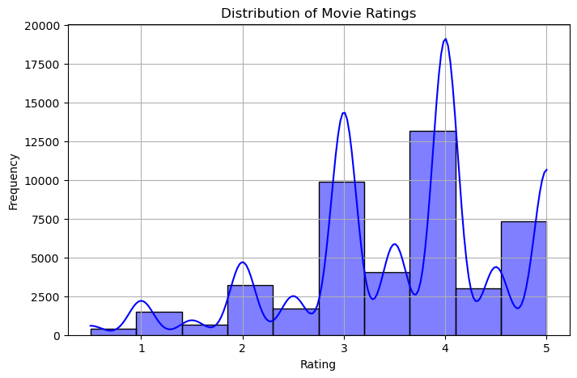

```python
import pandas as pd
import matplotlib.pyplot as plt
import seaborn as sns

df = pd.read_csv("cleaned_movie_ratings.csv")


plt.figure(figsize=(8, 5))
sns.histplot(df['rating'], bins=10, kde=True, color='blue')
plt.title("Distribution of Movie Ratings")
plt.xlabel("Rating")
plt.ylabel("Frequency")
plt.grid(True)
plt.show()
```

The plot shows the frequency distribution of movie ratings given by users.

✅ **This indicates that users are generally generous with their ratings, and most movies in the dataset are rated favorably.**

### 2. What are the most common genres in the dataset?

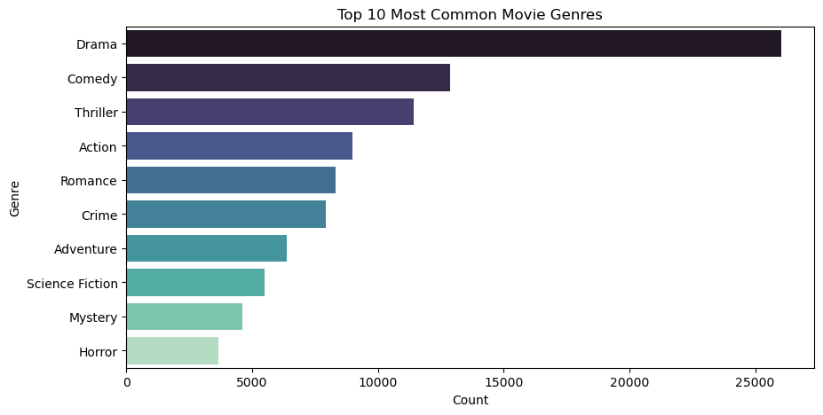

```python
from collections import Counter

# Split genres and count
genre_counts = df['genres'].dropna().str.split(', ').explode().value_counts().head(10)

plt.figure(figsize=(10, 5))
sns.barplot(x=genre_counts.values, y=genre_counts.index, palette="mako")
plt.title("Top 10 Most Common Movie Genres")
plt.xlabel("Count")
plt.ylabel("Genre")
plt.show()
```

The bar chart illustrates the **ten most frequently occurring genres** in the movie dataset.

- **Drama** clearly stands out as the most dominant genre, followed by **Comedy** and **Thriller**, indicating these genres are the most commonly produced or available.
- Other popular genres include **Action**, **Romance**, and **Crime**, which also have significant representation.
- Genres such as **Adventure**, **Science Fiction**, **Mystery**, and **Horror** round out the list, with slightly lower frequencies but still a notable presence.

✅ **Overall**, the chart reveals a strong preference for emotionally driven and entertaining content, with a balanced mix of suspense, action, and imagination across the dataset.

### 3. What are the top 10 most popular and most highly rated movies

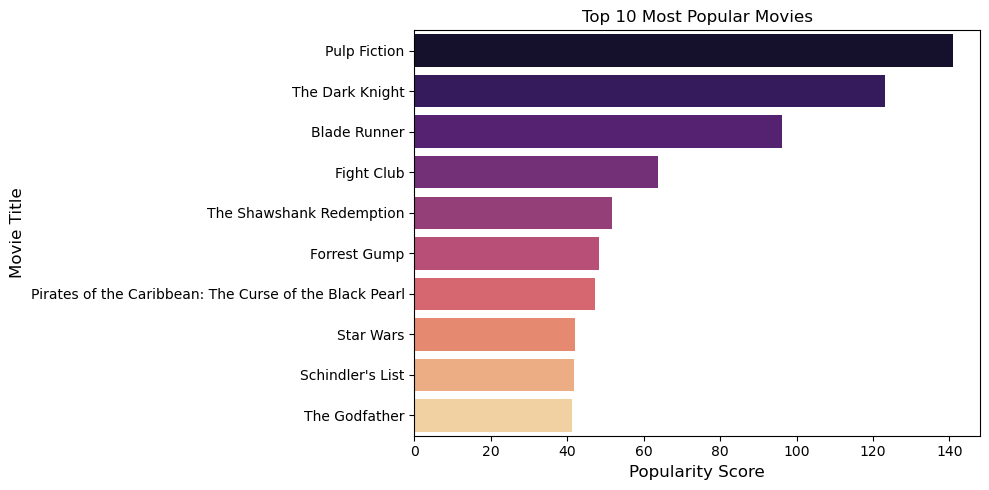

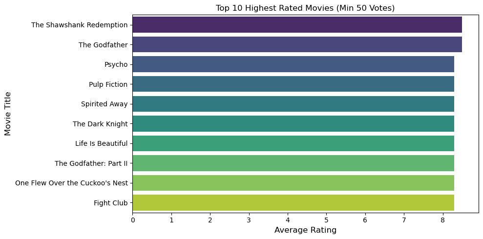

```python
import pandas as pd
import matplotlib.pyplot as plt
import seaborn as sns

df = pd.read_csv("cleaned_movie_ratings.csv")

df['popularity'] = pd.to_numeric(df['popularity'], errors='coerce')
df['vote_average'] = pd.to_numeric(df['vote_average'], errors='coerce')
df['vote_count'] = pd.to_numeric(df['vote_count'], errors='coerce')


# Top 10 Most Popular Movies
top_popular = df.sort_values(by='popularity', ascending=False)[['title', 'popularity']].drop_duplicates().head(10)

plt.figure(figsize=(10, 5))
sns.barplot(data=top_popular, y='title', x='popularity', palette='magma')
plt.title("Top 10 Most Popular Movies", fontsize=12)
plt.xlabel("Popularity Score", fontsize=12)
plt.ylabel("Movie Title", fontsize=12)
plt.xticks(fontsize=10)
plt.yticks(fontsize=10)
plt.tight_layout()
plt.show()


# Top 10 Highest Rated Movies (min 50 votes)
top_rated = df[df['vote_count'] >= 50].sort_values(by='vote_average', ascending=False)[['title', 'vote_average', 'vote_count']].drop_duplicates().head(10)

plt.figure(figsize=(10, 5))
sns.barplot(data=top_rated, y='title', x='vote_average', palette='viridis')
plt.title("Top 10 Highest Rated Movies (Min 50 Votes)", fontsize=12)
plt.xlabel("Average Rating", fontsize=12)
plt.ylabel("Movie Title", fontsize=12)
plt.xticks(fontsize=10)
plt.yticks(fontsize=10)
plt.tight_layout()
plt.show()
```

The bar chart illustrates the **"Top 10 Most Popular Movies,"** ranking them based on their popularity scores.

✅ **Overall**, this chart effectively highlights the pronounced popularity differences between the movies, providing valuable insight into audience preferences that could be leveraged in targeted recommendations.

The bar chart presents the **"Top 10 Highest Rated Movies"** (minimum of 50 votes), ordered by their average ratings.

- The top-rated movies, **The Shawshank Redemption** and **The Godfather**, lead with nearly identical average ratings, closely followed by classics like **Psycho** and **Pulp Fiction**.
- Other highly regarded films include **Spirited Away**, **The Dark Knight**, and **Life Is Beautiful**, all showing very similar high ratings around **8 out of 10**.
- **The Godfather: Part II**, **One Flew Over the Cuckoo's Nest**, and **Fight Club** also earn places among the highest-rated movies, although slightly lower compared to the leading titles.

✅ **Interestingly**, while *Pulp Fiction* was the clear standout in popularity, it ranks slightly lower in terms of average rating, indicating that high popularity doesn't always correlate perfectly with the highest user ratings. This information is valuable in balancing recommendations between popular and critically acclaimed films.

### 4. What is the relationship between budget and revenue?

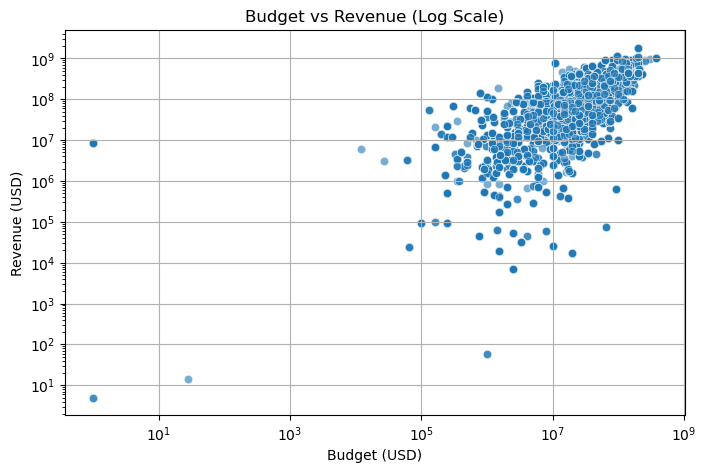

```python
df['budget'] = pd.to_numeric(df['budget'], errors='coerce')
df['revenue'] = pd.to_numeric(df['revenue'], errors='coerce')
filtered = df[(df['budget'] > 0) & (df['revenue'] > 0)]

plt.figure(figsize=(8, 5))
sns.scatterplot(data=filtered, x='budget', y='revenue', alpha=0.6)
plt.xscale('log')
plt.yscale('log')
plt.title("Budget vs Revenue (Log Scale)")
plt.xlabel("Budget (USD)")
plt.ylabel("Revenue (USD)")
plt.grid(True)
plt.show()
```

The scatterplot displays the relationship between **movie budget and revenue**, both presented on a logarithmic scale (USD).

- The overall trend suggests a **positive correlation**: as budgets increase, movie revenues generally increase as well.
- However, significant **variability** is evident, with many movies achieving relatively lower revenues despite substantial budgets, indicating that a higher budget does not guarantee higher earnings.
- Additionally, a few movies with very low budgets managed to generate unexpectedly high revenues, highlighting **outliers** of highly profitable low-budget films.

✅ **This scatterplot effectively underscores the risky and uncertain nature of film investment**, demonstrating that while increased budgets correlate with higher revenues, outcomes can still vary widely.

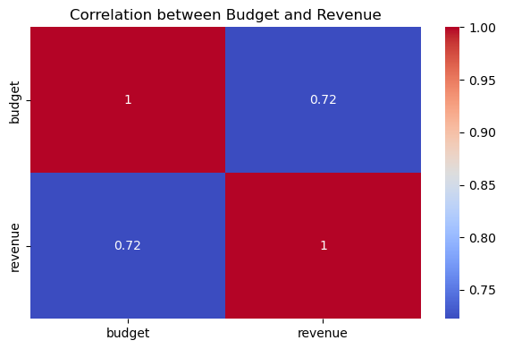

```python
plt.figure(figsize=(6, 4))
sns.heatmap(df[['budget', 'revenue']].corr(), annot=True, cmap='coolwarm')
plt.title('Correlation between Budget and Revenue')
plt.tight_layout()
plt.show()
```

The heatmap illustrates the **correlation between a movie's budget and its revenue**.

- The correlation coefficient of **0.72** indicates a **strong positive relationship**, suggesting that films with higher production budgets generally tend to earn more at the box office.
- However, the correlation is not perfect, meaning that while budget is a significant factor, other elements such as **cast**, **genre**, **marketing**, **critical reception**, and **audience appeal** also contribute to a movie’s financial success.
- The diagonal values of **1.0** simply reflect perfect self-correlation (e.g., budget with itself).

✅ **Overall**, the plot supports the idea that increased investment in production is often associated with higher revenue, but it’s not the sole determinant of a film’s performance.

### 5. Which movies had the highest and lowest budgets?

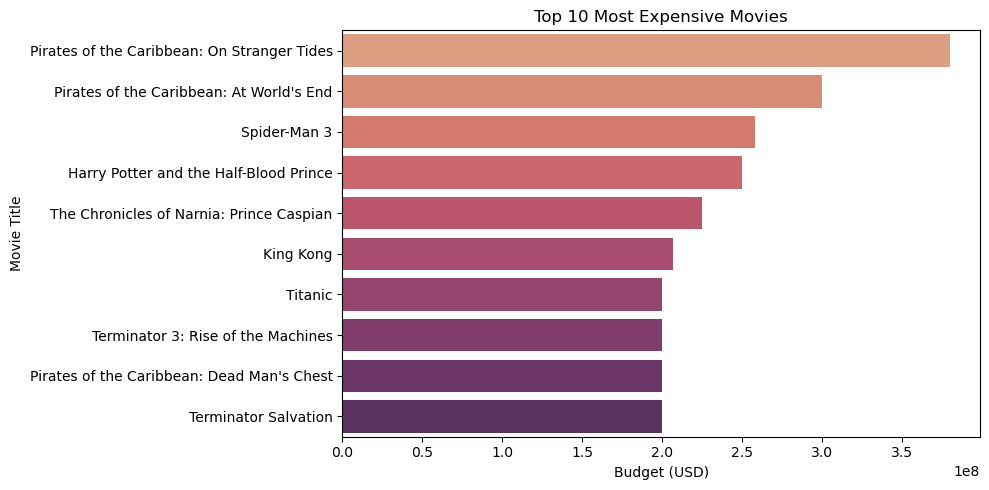

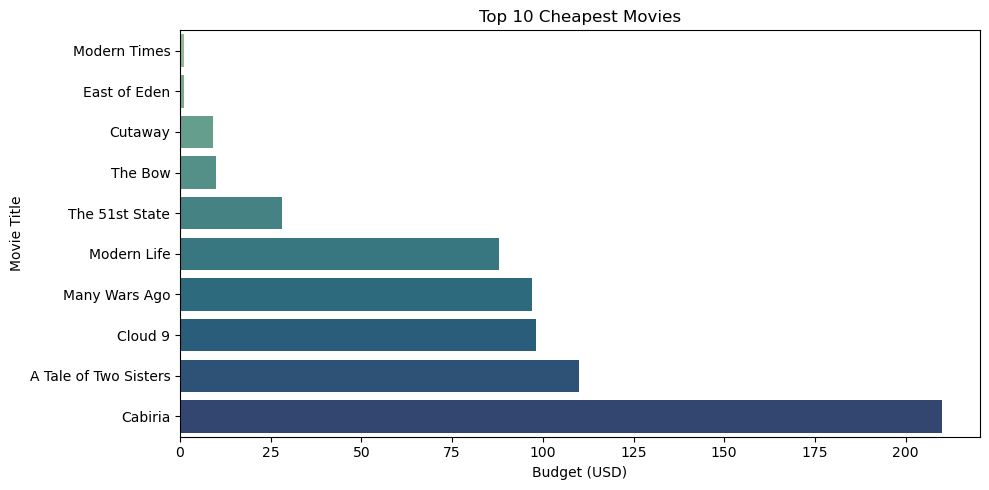

```python
import pandas as pd
import matplotlib.pyplot as plt
import seaborn as sns


df = pd.read_csv("cleaned_movie_ratings.csv")

df['budget'] = pd.to_numeric(df['budget'], errors='coerce')

# Filter valid (non-zero) budgets
valid_budget_df = df[df['budget'] > 0]

# Top 10 most expensive movies
top_expensive = valid_budget_df.sort_values(by='budget', ascending=False)[['title', 'budget']].drop_duplicates().head(10)

# Top 10 cheapest movies (excluding budget=0)
top_cheapest = valid_budget_df.sort_values(by='budget', ascending=True)[['title', 'budget']].drop_duplicates().head(10)

# Plot for most expensive movies
plt.figure(figsize=(10, 5))
sns.barplot(x='budget', y='title', data=top_expensive, palette='flare')
plt.title("Top 10 Most Expensive Movies", fontsize=12)
plt.xlabel("Budget (USD)")
plt.ylabel("Movie Title")
plt.tight_layout()
plt.show()

# Plot for cheapest movies
plt.figure(figsize=(10, 5))
sns.barplot(x='budget', y='title', data=top_cheapest, palette='crest')
plt.title("Top 10 Cheapest Movies", fontsize=12)
plt.xlabel("Budget (USD)")
plt.ylabel("Movie Title")
plt.tight_layout()
plt.show()
```

The bar chart illustrates the **"Top 10 Most Expensive Movies,"** ranked by their production budgets in USD.

- Clearly leading the list is **Pirates of the Caribbean: On Stranger Tides**, with the highest budget exceeding **350 million USD**. It is closely followed by another film in the same series, **Pirates of the Caribbean: At World's End**.
- Other movies in the top tier of high budgets include major franchises and blockbuster hits like **Spider-Man 3**, **Harry Potter and the Half-Blood Prince**, and **The Chronicles of Narnia: Prince Caspian**, each with budgets around or above **200 million USD**.
- Additionally, well-known blockbusters such as **King Kong**, **Titanic**, **Terminator 3: Rise of the Machines**, **Pirates of the Caribbean: Dead Man's Chest**, and **Terminator Salvation** round out the list, demonstrating significant investments.

✅ **This visualization emphasizes the massive financial commitments studios make for popular franchises and blockbuster films**, yet as previous data indicated, these large budgets do not necessarily guarantee proportional revenue or critical acclaim.

The bar chart illustrates the **ten movies produced with the lowest budgets**, highlighting how filmmaking can be achieved even with minimal financial resources.

- Films like **Modern Times** and **East of Eden** had budgets so small they're hardly visible, suggesting they were created under exceptionally frugal conditions.
- Slightly higher but still very low-budget films, including **Cutaway**, **The Bow**, and **The 51st State**, clearly show modest financial investment compared to typical movies.
- Even the most costly among these low-budget films, **Cabiria**, barely exceeds **$200 USD**.

✅ **This visualization emphasizes that compelling storytelling and impactful cinema do not necessarily depend on high production costs**, presenting an insightful contrast to high-budget blockbuster productions.

### 6. How many movies are released each year?

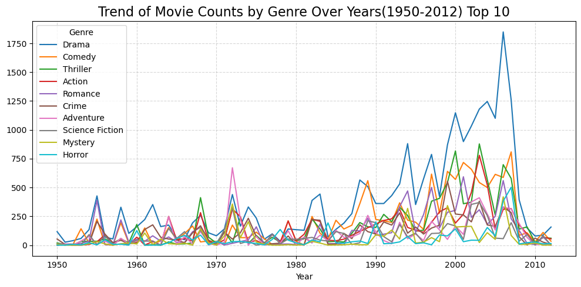

```python
merged_df['genres'] = merged_df['genres'].str.split(', ')
exploded_df = merged_df.explode('genres')
exploded_df.dropna(subset='release_date',inplace=True)
exploded_df['year']=exploded_df['release_date'].apply(lambda x:x[:4])
exploded_df['year'] = exploded_df['year'].astype(int)
filtered_df = exploded_df[(exploded_df['year'] >= 1950) & (exploded_df['year'] <= 2012)]
genre_year_counts =filtered_df.groupby(['year', 'genres']).size().unstack(fill_value=0)

plt.figure(figsize=(10, 5))
##select the top 6 genres to demonstrate
top_genres = genre_year_counts.sum().sort_values(ascending=False).head(10).index

for genre in top_genres:
    plt.plot(genre_year_counts.index, genre_year_counts[genre], label=genre)

plt.title('Trend of Movie Counts by Genre Over Years(1950-2012) Top 10', fontsize=16)
plt.xlabel('Year')
plt.legend(title='Genre')
plt.grid(True, linestyle='--', alpha=0.5)
plt.tight_layout()

plt.show()
```

#### Line Plot Analysis: Trend of Movie Counts by Genre Over Years (1950–2012) – Top 10

This trend highlights the **growing diversity and demand** in the film industry over the decades.

# **Implementing recommendation models**

- Popularity-Based Recommendation – Recommends trending/highly rated movies.
- Content-Based Recommendation – Uses genres, overview, and metadata to suggest similar movies.
- Collaborative Filtering (User-User or Item-Item) – Suggests movies based on user preferences.
- Hybrid Model – Combines multiple techniques for better results.

## **Popularity-Based Recommendation**

The Popularity-Based Recommendation System has been successfully executed, displaying the top 10 most popular movies based on vote average, vote count, and popularity score.

```python
import pandas as pd

file_path = "cleaned_movie_ratings.csv"
cleaned_df = pd.read_csv(file_path)

# Define a function to recommend movies based on popularity and ratings
def recommend_popular_movies(n=10, min_votes=50):
    """Recommends the top N popular movies with at least min_votes, removing duplicates."""
    popular_movies = cleaned_df[cleaned_df["vote_count"] >= min_votes]
    popular_movies = popular_movies.sort_values(by=["vote_average", "vote_count"], ascending=[False, False])

    # Remove duplicate movie titles while keeping the first occurrence
    popular_movies = popular_movies.drop_duplicates(subset="title")

    return popular_movies[["title", "vote_average", "vote_count", "popularity"]].head(n)


top_popular_movies = recommend_popular_movies(n=10, min_votes=50)


top_popular_movies.head(10)
```

|  | title | vote_average | vote_count | popularity |
| --- | --- | --- | --- | --- |
| 19241 | The Shawshank Redemption | 8.5 | 8358.0 | 51.645403 |
| 3542 | The Godfather | 8.5 | 6024.0 | 41.109264 |
| 19681 | The Dark Knight | 8.3 | 12269.0 | 123.167259 |
| 52 | Fight Club | 8.3 | 9678.0 | 63.869599 |
| 608 | Pulp Fiction | 8.3 | 8670.0 | 140.950236 |
| 2235 | Schindler's List | 8.3 | 4436.0 | 41.725123 |
| 44624 | Spirited Away | 8.3 | 3968.0 | 41.048867 |
| 3207 | Life Is Beautiful | 8.3 | 3643.0 | 39.394970 |
| 11184 | The Godfather: Part II | 8.3 | 3418.0 | 36.629307 |
| 4586 | One Flew Over the Cuckoo's Nest | 8.3 | 3001.0 | 35.529554 |

## **Content-Based Recommendation System**

**Content-based filtering** is a recommendation approach that suggests movies similar to a given title by analyzing movie features, such as genres, descriptions, or keywords. Unlike collaborative filtering, which relies on user behavior, content-based filtering focuses purely on item metadata to make suggestions.

In the provided code, a **content-based movie recommendation system** is implemented using:

- **TF-IDF Vectorization**:  
  This transforms the genres column into a numerical format, highlighting unique and meaningful genre combinations for each movie.
- **K-Nearest Neighbors (KNN)**:  
  Once each movie's genre profile is converted into a vector, the KNN algorithm (with cosine similarity) is used to find other movies with similar genre patterns.

The function `recommend_movies_by_knn()` takes a movie title (e.g., `"The Dark"`) and returns a list of top **N** similar movies based on genre similarity.

✅ **This system is especially useful for new users or when there is no user interaction history available**, as it only needs the content of the items themselves to generate recommendations.

### Recommends similar movies using KNN based on content (overview)

```python
import pandas as pd
from sklearn.feature_extraction.text import TfidfVectorizer
from sklearn.neighbors import NearestNeighbors


cleaned_data_path = "cleaned_movie_ratings.csv"
cleaned_df = pd.read_csv(cleaned_data_path)

# Content-Based Recommendation System using KNN
cleaned_df['overview'] = cleaned_df['overview'].fillna('')
tfidf_vectorizer = TfidfVectorizer(stop_words='english', max_features=5000)
tfidf_matrix = tfidf_vectorizer.fit_transform(cleaned_df['overview'])

knn_model = NearestNeighbors(metric='cosine', algorithm='brute', n_neighbors=11)
knn_model.fit(tfidf_matrix)

title_to_index = pd.Series(cleaned_df.index, index=cleaned_df['title']).drop_duplicates()

def recommend_movies_knn(movie_title, n=10):
    """Recommends similar movies using KNN based on content (overview), ensuring unique titles."""
    if movie_title not in title_to_index:
        return pd.DataFrame({"Error": [f"Movie '{movie_title}' not found in dataset."]})

    idx = title_to_index[movie_title]
    distances, indices = knn_model.kneighbors(tfidf_matrix[idx], n_neighbors=n+20)  # Fetch extra in case of duplicates

    movie_indices = indices[0][1:]  # Exclude the first index (the movie itself)
    recommended_movies = cleaned_df.iloc[movie_indices][["title", "overview", "vote_average", "vote_count"]]

    # Remove duplicate movie titles while keeping the first occurrence
    recommended_movies = recommended_movies.drop_duplicates(subset="title").head(n)

    return recommended_movies


movie_title = "Wedlock"


recommended_movies = recommend_movies_knn(movie_title, n=50)


recommended_movies
```

|  | title | overview | vote_average | vote_count |
| --- | --- | --- | --- | --- |
| 34007 | Wedlock | A male prison escapee heads for his hidden loo... | 5.7 | 26.0 |
| 31241 | What Have You Done to Solange? | After several coeds are murdered at a college,... | 7.2 | 30.0 |
| 33651 | Goodbye Bafana | The true story of a white South African racist... | 7.0 | 38.0 |
| 35452 | Innocence | Yusuf is released from prison after serving a ... | 8.6 | 8.0 |
| 35064 | The Shawshank Redemption | Framed in the 1940s for the double murder of h... | 8.5 | 8358.0 |
| 3766 | Cockpit | After getting fired from his current job as a ... | 5.1 | 8.0 |
| 4982 | Gaslight | Twenty years after the murder of Alice Barlow,... | 7.1 | 20.0 |
| 1170 | The Count of Monte-Cristo | A TV adaptation of the classic Alexandre Dumas... | 6.1 | 30.0 |
| 30333 | The Bear | An orphan bear cub hooks up with an adult male... | 6.9 | 85.0 |
| 14972 | Willy Wonka & the Chocolate Factory | Eccentric candy man Willy Wonka prompts a worl... | 7.4 | 826.0 |

### Recommends movies using KNN based on genres

```python
import pandas as pd
import numpy as np
from sklearn.feature_extraction.text import TfidfVectorizer
from sklearn.neighbors import NearestNeighbors


cleaned_data_path = "cleaned_movie_ratings.csv"
cleaned_df = pd.read_csv(cleaned_data_path)

# Content-Based Recommendation System using KNN on Genres
cleaned_df['genres'] = cleaned_df['genres'].fillna('')

tfidf_vectorizer = TfidfVectorizer(stop_words='english')
tfidf_matrix = tfidf_vectorizer.fit_transform(cleaned_df['genres'])

# Fit KNN model
knn_model = NearestNeighbors(metric='cosine', algorithm='brute', n_neighbors=11)
knn_model.fit(tfidf_matrix)

# Create a mapping of movie titles to indices
title_to_index = pd.Series(cleaned_df.index, index=cleaned_df['title']).drop_duplicates()

def recommend_movies_by_knn(movie_title, n=10):
    """Recommends movies using KNN based on genres."""
    if movie_title not in title_to_index:
        return pd.DataFrame({"Error": [f"Movie '{movie_title}' not found in dataset."]})

    idx = title_to_index[movie_title]
    distances, indices = knn_model.kneighbors(tfidf_matrix[idx], n_neighbors=n+1)

    movie_indices = indices[0][1:]  # Exclude the first index (the movie itself)
    recommended_movies = cleaned_df.iloc[movie_indices][["title", "genres", "vote_average", "vote_count"]]

    # Remove duplicate movie titles while keeping the first occurrence
    recommended_movies = recommended_movies.drop_duplicates(subset="title").head(n)

    return recommended_movies


movie_title = "The Dark"
recommended_movies = recommend_movies_by_knn(movie_title, n=50)

print("Content-Based Filtering Model using KNN on Genres is ready.")
recommended_movies
```

```
Content-Based Filtering Model using KNN on Genres is ready.
```

|  | title | genres | vote_average | vote_count |
| --- | --- | --- | --- | --- |
| 491 | The Dark | Horror, Thriller, Mystery | 5.6 | 76.0 |
| 19790 | Angel Heart | Horror, Mystery, Thriller | 7.0 | 326.0 |
| 16953 | In the Mouth of Madness | Horror, Mystery, Thriller | 7.1 | 307.0 |
| 2587 | Dust Devil | Horror, Mystery, Thriller | 6.7 | 34.0 |
| 29149 | The Grudge | Horror, Mystery, Thriller | 5.8 | 889.0 |
| 26712 | Lord of Illusions | Mystery, Horror, Thriller | 5.9 | 87.0 |
| 38763 | I Still Know What You Did Last Summer | Horror, Mystery, Thriller | 5.1 | 381.0 |
| 26379 | The Grudge 3 | Mystery, Horror, Thriller | 5.3 | 150.0 |

### **Model Performance for Content Based Filtering**

This code evaluates a Content-Based Filtering model (based on genres) by using vote_average as a proxy for predicted ratings and comparing it to the actual user rating (rating) using several evaluation metrics: RMSE, MAE, Accuracy, Precision, Recall, and F1 Score.

```python
import pandas as pd
import numpy as np
from sklearn.metrics import mean_squared_error, mean_absolute_error, accuracy_score, precision_score, recall_score, f1_score

# Load the dataset
df = pd.read_csv("cleaned_movie_ratings.csv")

# Simulate recommendations based on genres
df['genres'] = df['genres'].fillna('')
df['predicted_rating'] = df['vote_average']  # Using vote_average as a proxy for predicted score
df['actual_rating'] = df['rating']  # Ground truth from user ratings

# Drop rows with missing actual ratings
df = df.dropna(subset=['actual_rating'])

# Clip predicted ratings to valid range
df['predicted_rating'] = df['predicted_rating'].clip(0.5, 5.0)

# Binary labels: relevant if rating >= 3.5
df['true_label'] = (df['actual_rating'] >= 3.5).astype(int)
df['pred_label'] = (df['predicted_rating'] >= 3.5).astype(int)

# Evaluation metrics
rmse = mean_squared_error(df['actual_rating'], df['predicted_rating'], squared=False)
mae = mean_absolute_error(df['actual_rating'], df['predicted_rating'])
accuracy = accuracy_score(df['true_label'], df['pred_label'])
precision = precision_score(df['true_label'], df['pred_label'])
recall = recall_score(df['true_label'], df['pred_label'])
f1 = f1_score(df['true_label'], df['pred_label'])

{
    "RMSE": round(rmse, 4),
    "MAE": round(mae, 4),
    "Accuracy": round(accuracy, 4),
    "Precision": round(precision, 4),
    "Recall": round(recall, 4),
    "F1 Score": round(f1, 4)
}
```

```
{'RMSE': 1.7817,
 'MAE': 1.4352,
 'Accuracy': 0.6079,
 'Precision': 0.6117,
 'Recall': 0.9849,
 'F1 Score': 0.7547}
```

## **Collaborative Based Filtering Model**

**Collaborative filtering** is a recommendation technique that suggests movies to users based on the preferences of other users with similar tastes.

- It identifies **patterns in user ratings** and predicts how much a user might like a movie they haven't seen yet.
- Unlike content-based filtering, it **does not rely on movie content** (e.g., genre or description).
- Instead, it leverages the **behavior and ratings of many users** to generate personalized recommendations.

It assumes that if two users liked the same movies in the past, they will likely enjoy similar movies in the future. The system looks at the behavior patterns of users, such as ratings.

- It finds similar users or items based on those patterns.
- If User A and User B rate several movies similarly, then User A might like movies that User B liked but User A hasn’t seen yet.

### **Collaborative Filtering with Singular Value Decomposition (SVD)**

This collaborative filtering system is built using **Singular Value Decomposition (SVD)**, a model-based approach to recommending movies based on user preferences.

- The system loads a cleaned dataset of user ratings and prepares it using the **Surprise library**.
- The **SVD model** is trained on a subset of the data to learn latent features that capture relationships between users and movies.
- It **predicts** how a user might rate unseen movies by identifying patterns from other users with similar tastes.
- The app then recommends the **top N movies** for a selected user by sorting predicted ratings in descending order.

```python
import pandas as pd
from surprise import Dataset, Reader, SVD
from surprise.model_selection import train_test_split

df = pd.read_csv("cleaned_movie_ratings.csv")


reader = Reader(rating_scale=(0.5, 5.0))
data = Dataset.load_from_df(df[['userId', 'movieId', 'rating']], reader)

# Split data into train and test sets
trainset, testset = train_test_split(data, test_size=0.2, random_state=42)
```

```python
# Initialize and train the model
svd = SVD()
svd.fit(trainset)
```

```
<surprise.prediction_algorithms.matrix_factorization.SVD at 0x16a18e150>
```

```python
# Predict a specific user-movie rating
user_id = 1
movie_id = 120
prediction = svd.predict(user_id, movie_id)
print(f"Predicted rating for User {user_id} on Movie {movie_id}: {prediction.est:.2f}")
```

```
Predicted rating for User 1 on Movie 120: 3.09
```

```python
def get_top_n_recommendations(user_id, df, model, n=10):
    rated_movies = df[df['userId'] == user_id]['movieId'].tolist()
    all_movies = df['movieId'].unique()
    to_predict = [m for m in all_movies if m not in rated_movies]

    predictions = [model.predict(user_id, movie_id) for movie_id in to_predict]
    top_preds = sorted(predictions, key=lambda x: x.est, reverse=True)[:n]

    movie_map = df[['movieId', 'title']].drop_duplicates().set_index('movieId')['title'].to_dict()
    return [(movie_map.get(pred.iid, 'Unknown'), round(pred.est, 2)) for pred in top_preds]

top_recs = get_top_n_recommendations(user_id=1, df=df, model=svd, n=10)
for title, score in top_recs:
    print(f"{title}: {score}")
```

```
Sleepless in Seattle: 4.13
Birdman of Alcatraz: 4.12
Shriek If You Know What I Did Last Friday the Thirteenth: 3.97
Longitude: 3.96
Miffo: 3.96
The Million Dollar Hotel: 3.95
Galaxy Quest: 3.94
The Green Mile: 3.92
Confession of a Child of the Century: 3.91
The Red Elvis: 3.88
```

### **Model Performance for Collaborative Filtering**

```python
import pandas as pd
from surprise import Dataset, Reader, SVD
from surprise.model_selection import train_test_split
from surprise import accuracy
from sklearn.metrics import accuracy_score, precision_score, recall_score, f1_score, mean_squared_error, mean_absolute_error


# Get predictions on test set
predictions = svd.test(testset)

# Actual and predicted ratings
y_true = [pred.r_ui for pred in predictions]
y_pred = [pred.est for pred in predictions]

# Regression metrics
rmse = mean_squared_error(y_true, y_pred, squared=False)
mae = mean_absolute_error(y_true, y_pred)

# Convert to binary labels (e.g., relevant = rating ≥ 3.5)
threshold = 3.5
y_true_bin = [1 if r >= threshold else 0 for r in y_true]
y_pred_bin = [1 if r >= threshold else 0 for r in y_pred]

# Classification metrics
accuracy_val = accuracy_score(y_true_bin, y_pred_bin)
precision_val = precision_score(y_true_bin, y_pred_bin)
recall_val = recall_score(y_true_bin, y_pred_bin)
f1_val = f1_score(y_true_bin, y_pred_bin)


print("\n Evaluation Metrics (on Test Set):")
print(f"RMSE      : {rmse:.4f}")
print(f"MAE       : {mae:.4f}")
print(f"Accuracy  : {accuracy_val:.4f}")
print(f"Precision : {precision_val:.4f}")
print(f"Recall    : {recall_val:.4f}")
print(f"F1 Score  : {f1_val:.4f}")
```

```
 Evaluation Metrics (on Test Set):
RMSE      : 0.9038
MAE       : 0.6952
Accuracy  : 0.6982
Precision : 0.7823
Recall    : 0.7067
F1 Score  : 0.7426
```

##### **Model Performance Metrics**

[output not shown]

### **Limitations of Collaborative Filtering**

##### **Cold Start Problem**

- Collaborative filtering struggles with **new users** or **new movies** that have **no prior ratings**.
- Without sufficient historical data, the model cannot make accurate predictions or recommendations.

##### **Solutions to the Cold Start Problem:**

1. **Hybrid Recommendation Systems**:
   - Combine collaborative filtering with content-based filtering.
   - Leverage movie metadata (genres, descriptions, keywords) to generate recommendations when rating data is unavailable.
2. **Content-based User Onboarding**:
   - Ask new users to select preferred genres or rate a few initial movies.
   - Quickly establish an initial user preference profile.
3. **Popularity-based Recommendations**:
   - Temporarily suggest trending or top-rated movies to new users until enough interaction data is collected.

## **Hybrid model**

A Hybrid Recommendation System combines two or more recommendation techniques—such as collaborative filtering, content-based filtering, and popularity-based methods—to generate more accurate, personalized, and robust recommendations. Each individual approach has its strengths and limitations. For instance, collaborative filtering can suffer from the cold start problem for new users or items, while content-based methods may be limited in diversity. By blending these approaches, hybrid models aim to overcome these weaknesses and leverage the strengths of each method.

In the context of movie recommendations, a hybrid model might use user-item rating patterns (collaborative filtering) and movie metadata like genres or overviews (content-based filtering) together. For example, it can recommend movies that are both similar in content to a movie the user liked and are also liked by users with similar preferences. This leads to more accurate and relevant recommendations, especially in sparse or noisy datasets.

This hybrid recommendation system effectively combines **content-based filtering** and **collaborative filtering** to deliver personalized and accurate movie recommendations.

##### **Step 1: Content-Based Filtering**

- **TF-IDF Vectorization**  
  Transforms movie genres into numerical vectors capturing meaningful genre combinations.
- **K-Nearest Neighbors (KNN)**  
  Uses cosine similarity to identify genre-similar movies based on the user's selected movie.

##### **Step 2: Collaborative Filtering**

- **Singular Value Decomposition (SVD)**
  - Implemented using the `surprise` library.
  - SVD is trained on the userId, movieId, rating data and learns latent features (patterns) of user preferences.
  - For each content-similar movie found in step 1, the model predicts how much the input user would like that movie using SVD.

##### **Step 3: Hybrid Scoring**

The system combines both content and collaborative filtering using a hybrid score:

hybrid_score = (vote_average + svd_score) / 2

- vote_average captures how good the movie is generally (public opinion).
- svd_score captures how likely the specific user is to enjoy the movie.

Movies are then sorted by this hybrid score, and the top-N are returned as recommendations.

```python
import streamlit as st
import pandas as pd
import numpy as np
from sklearn.feature_extraction.text import TfidfVectorizer
from sklearn.neighbors import NearestNeighbors
from surprise import Dataset, Reader, SVD

# Load cleaned data
df = pd.read_csv("cleaned_movie_ratings.csv")
df['genres'] = df['genres'].fillna('')

# --- Collaborative Filtering Setup (SVD) ---
reader = Reader(rating_scale=(0.5, 5.0))
data = Dataset.load_from_df(df[['userId', 'movieId', 'rating']], reader)
trainset = data.build_full_trainset()
svd_model = SVD()
svd_model.fit(trainset)

# --- Content-Based Filtering Setup (KNN on genres) ---
tfidf_vectorizer = TfidfVectorizer(stop_words='english')
tfidf_matrix = tfidf_vectorizer.fit_transform(df['genres'])
knn_model = NearestNeighbors(metric='cosine', algorithm='brute', n_neighbors=200)
knn_model.fit(tfidf_matrix)

# --- Mappings ---
title_to_index = pd.Series(df.index, index=df['title']).drop_duplicates()

# --- Hybrid Recommendation Function ---
def recommend_hybrid(movie_title, user_id, n=10):
    if movie_title not in title_to_index:
        return pd.DataFrame({"Error": [f"Movie '{movie_title}' not found in dataset."]})

    idx = title_to_index[movie_title]
    distances, indices = knn_model.kneighbors(tfidf_matrix[idx], n_neighbors=200)
    movie_indices = indices[0][1:]

    recommendations = df.iloc[movie_indices][["movieId", "title", "vote_average", "genres"]]
    recommendations = recommendations.drop_duplicates(subset="title")  # ensure unique titles

    # Add collaborative SVD predictions
    recommendations["svd_score"] = recommendations["movieId"].apply(lambda x: svd_model.predict(user_id, x).est)

    # Combine to hybrid score
    recommendations["hybrid_score"] = (recommendations["vote_average"] + recommendations["svd_score"]) / 2

    return recommendations.sort_values(by="hybrid_score", ascending=False).head(n)


# Sample input
movie_input = "The Dark Knight"
user_id_input = 1
top_n = 10

# Get recommendations
recommended_movies = recommend_hybrid(movie_input, user_id_input, n=top_n)

# Display the result
print(f"\n🎯 Top {top_n} Hybrid Recommendations for User {user_id_input} based on '{movie_input}':\n")
print(recommended_movies[["title", "genres", "vote_average", "svd_score", "hybrid_score"]])
```

```
🎯 Top 10 Hybrid Recommendations for User 1 based on 'The Dark Knight':

                     title                          genres  vote_average  \
7159              Scarface  Action, Crime, Drama, Thriller           8.0
35567      The Dark Knight  Drama, Action, Crime, Thriller           8.3
20515                    M  Drama, Action, Thriller, Crime           8.0
38824          The Killing  Drama, Action, Thriller, Crime           7.7
6861                  Heat  Action, Crime, Drama, Thriller           7.7
38610              Bullitt  Action, Crime, Drama, Thriller           7.0
37991  Running Out of Time  Drama, Action, Thriller, Crime           7.5
7873          Training Day  Action, Crime, Drama, Thriller           7.3
6892          Street Kings  Action, Crime, Drama, Thriller           6.3
6993               Payback  Drama, Action, Thriller, Crime           6.7

       svd_score  hybrid_score
7159    3.567614      5.783807
35567   2.979542      5.639771
20515   3.132904      5.566452
38824   3.334410      5.517205
6861    3.153104      5.426552
38610   3.764559      5.382279
37991   3.258383      5.379192
7873    3.009745      5.154873
6892    3.423355      4.861678
6993    3.017693      4.858846
```

### **Model Performance for Hybrid Model**

```python
import pandas as pd
from surprise import Dataset, Reader, SVD
from surprise.model_selection import train_test_split
from sklearn.metrics import mean_squared_error, mean_absolute_error, accuracy_score, precision_score, recall_score, f1_score

df = pd.read_csv("cleaned_movie_ratings.csv").dropna(subset=["userId", "movieId", "rating", "vote_average"])

# Prepare Surprise dataset
reader = Reader(rating_scale=(0.5, 5.0))
data = Dataset.load_from_df(df[['userId', 'movieId', 'rating']], reader)

# Train-test split
trainset, testset = train_test_split(data, test_size=0.2, random_state=42)
svd = SVD()
svd.fit(trainset)

# Predict and merge with content-based scores
predictions = svd.test(testset)
pred_df = pd.DataFrame([(p.uid, p.iid, p.r_ui, p.est) for p in predictions], columns=["userId", "movieId", "actual", "svd_pred"])
vote_avg = df.drop_duplicates("movieId").set_index("movieId")["vote_average"]
pred_df["vote_average"] = pred_df["movieId"].map(vote_avg)
pred_df.dropna(inplace=True)
pred_df["hybrid_pred"] = (pred_df["svd_pred"] + pred_df["vote_average"]) / 2

# Evaluation
y_true = pred_df["actual"]
y_pred = pred_df["hybrid_pred"]
y_true_bin = (y_true >= 3.5).astype(int)
y_pred_bin = (y_pred >= 3.5).astype(int)

print("📊 Hybrid Model Evaluation")
print("RMSE:", round(mean_squared_error(y_true, y_pred, squared=False), 4))
print("MAE:", round(mean_absolute_error(y_true, y_pred), 4))
print("Accuracy:", round(accuracy_score(y_true_bin, y_pred_bin), 4))
print("Precision:", round(precision_score(y_true_bin, y_pred_bin), 4))
print("Recall:", round(recall_score(y_true_bin, y_pred_bin), 4))
print("F1 Score:", round(f1_score(y_true_bin, y_pred_bin), 4))
```

```
📊 Hybrid Model Evaluation
RMSE: 1.8807
MAE: 1.5991
Accuracy: 0.6144
Precision: 0.617
Recall: 0.9861
F1 Score: 0.7591
```

##### **Model Performance Metrics**

[output not shown]

## **Model Comparison: Collaborative (SVD) Model vs. Hybrid Model**

[output not shown]

#### **Best-Performing Model: Collaborative Filtering (SVD)**

Based on evaluating multiple recommendation approaches, the **Collaborative Filtering (SVD)** model demonstrates the strongest performance, particularly in terms of **Root Mean Squared Error (RMSE)**.

✅ **Conclusion**:  
The **Collaborative Filtering (SVD)** approach provides the most robust and accurate recommendation performance, making it the ideal choice for this recommendation system.

# **Movie Recommendation Webpage using Content based Filtering (Streamlit UI)**

Build an interactive webpage where the user can: The application is built with Streamlit, providing an intuitive and interactive web interface. Users can-

- **Search for a movie title.**
- **Get similar movie recommendations** based on genre similarity (**using TF-IDF vectorization and K-Nearest Neighbors**).

**Implementation Steps:**

1. **TF-IDF Vectorization**:
   - Transform the movie genre data into numerical vectors.
2. **K-Nearest Neighbors (KNN)**:
   - Calculate genre similarity between movies using cosine similarity.
   - Identify movies closest in genre profile to the selected title.
3. **Interactive Web Interface**:
   - Include a search box for users to input movie titles.
   - Display a list of recommended movies based on user input.

✅ **Result**: A user-friendly webpage providing content-based recommendations, ideal for new users without prior interaction data.

```python
with open("app.py", "w") as f:
    f.write('''import streamlit as st
import pandas as pd
import numpy as np
from sklearn.feature_extraction.text import TfidfVectorizer
from sklearn.neighbors import NearestNeighbors

# Load cleaned data
cleaned_data_path = "cleaned_movie_ratings.csv"
cleaned_df = pd.read_csv(cleaned_data_path)

# Content-Based Recommendation System using KNN on Genres
cleaned_df['genres'] = cleaned_df['genres'].fillna('')

tfidf_vectorizer = TfidfVectorizer(stop_words='english')
tfidf_matrix = tfidf_vectorizer.fit_transform(cleaned_df['genres'])

# Fit KNN model
knn_model = NearestNeighbors(metric='cosine', algorithm='brute', n_neighbors=11)
knn_model.fit(tfidf_matrix)

# Create a mapping of movie titles to indices
title_to_index = pd.Series(cleaned_df.index, index=cleaned_df['title']).drop_duplicates()

def recommend_movies_by_knn(movie_title, n=10):
    """Recommends movies using KNN based on genres."""
    if movie_title not in title_to_index:
        return pd.DataFrame({"Error": [f"Movie '{movie_title}' not found in dataset."]})

    idx = title_to_index[movie_title]
    distances, indices = knn_model.kneighbors(tfidf_matrix[idx], n_neighbors=n+1)

    movie_indices = indices[0][1:]  # Exclude the first index (the movie itself)
    recommended_movies = cleaned_df.iloc[movie_indices][["title", "genres", "vote_average", "vote_count"]]

    # Remove duplicate movie titles while keeping the first occurrence
    recommended_movies = recommended_movies.drop_duplicates(subset="title").head(n)

    return recommended_movies

# Streamlit UI
st.set_page_config(page_title="🎬 Content-Based Recommender", layout="centered")
st.title("🎬 Movie Recommendation System using Content Based Filtering")
st.subheader("Type and select a movie to get similar recommendations")

# 🔍 Searchable dropdown
movie_list = sorted(cleaned_df['title'].dropna().unique())
movie_input = st.selectbox("🎞️ Search and select a movie:", movie_list)

if st.button("Recommend"):
    recommendations = recommend_movies_by_knn(movie_input, n=100)
    st.write("### 🎯 Recommended Movies:")
    st.dataframe(recommendations)

''')

print("app.py file created successfully.")
```

```
app.py file created successfully.
```

```python
!streamlit run app.py
```

```
  You can now view your Streamlit app in your browser.

  Local URL: http://localhost:8501
  Network URL: http://10.12.178.158:8501
```

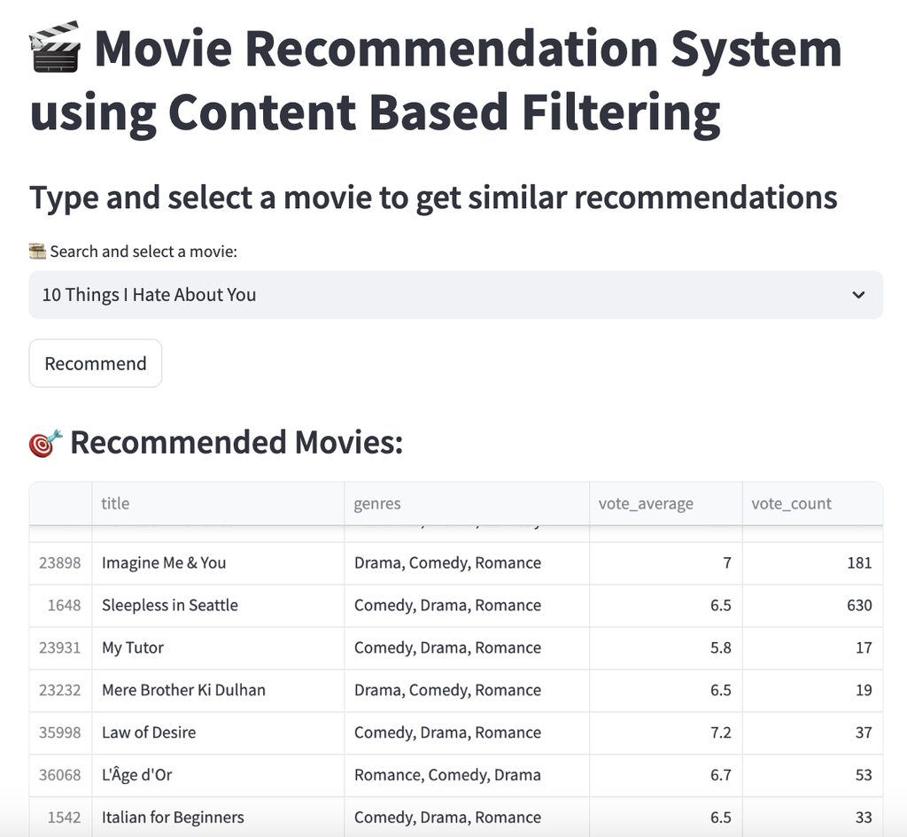

# **Movie Recommendation Webpage using Collaborative based Filtering (Streamlit UI)**

This project implements a **collaborative filtering-based movie recommendation system** using **Singular Value Decomposition (SVD)**. It leverages user rating data to learn patterns and suggest movies that a user is likely to enjoy, based on the preferences of similar users.

The application is built with **Streamlit**, providing an intuitive and interactive web interface. Users can:

- **Input their User ID** to receive personalized movie recommendations.
- **Predict ratings** for specific movies.

#### **How it Works:**

1. **Data Preparation**:  
   Loads and preprocesses the ratings dataset.
2. **Model Training (SVD)**:  
   Captures latent features of users and movies from user-item interactions.
3. **Personalized Recommendations**:  
   Identifies and recommends top-rated unseen movies for each user.
4. **Rating Prediction**:  
   Predicts how a specific user might rate an individual movie.

✅ **This approach** focuses entirely on user behavior and rating patterns, without needing metadata like genres or plot summaries. It’s ideal for personalization and demonstrates the effectiveness of collaborative filtering in real-world recommendation engines.

```python
with open("app1.py", "w") as f:
    f.write('''import streamlit as st
import pandas as pd
from surprise import Dataset, Reader, SVD
from surprise.model_selection import train_test_split

# --- Load the dataset ---
@st.cache_data
def load_data():
    return pd.read_csv("cleaned_movie_ratings.csv")

df = load_data()

# --- Prepare Surprise data and train SVD (cached) ---
@st.cache_resource
def train_model(dataframe):
    reader = Reader(rating_scale=(0.5, 5.0))
    data = Dataset.load_from_df(dataframe[['userId', 'movieId', 'rating']], reader)
    trainset, _ = train_test_split(data, test_size=0.2, random_state=42)
    model = SVD()
    model.fit(trainset)
    return model

svd = train_model(df)

# --- Create mapping for movie titles ---
movie_map = df[['movieId', 'title']].drop_duplicates().set_index('movieId')['title'].to_dict()
title_map = df[['title', 'movieId']].drop_duplicates().set_index('title')['movieId'].to_dict()

# --- Recommendation Function ---
def get_top_n_recommendations(user_id, df, model, n=10):
    rated_movies = df[df['userId'] == user_id]['movieId'].tolist()
    all_movies = df['movieId'].unique()
    to_predict = [m for m in all_movies if m not in rated_movies]

    predictions = [model.predict(user_id, movie_id) for movie_id in to_predict]
    top_preds = sorted(predictions, key=lambda x: x.est, reverse=True)[:n]

    return [(movie_map.get(pred.iid, 'Unknown'), round(pred.est, 2)) for pred in top_preds]

# --- Streamlit UI ---
st.title("🎬 Collaborative Filtering (SVD) Recommender")

user_id_input = st.number_input("Enter User ID:", min_value=1, step=1)
num_recs = st.slider("How many recommendations?", 5, 20, 10)

if st.button("Get Recommendations"):
    top_recs = get_top_n_recommendations(user_id=user_id_input, df=df, model=svd, n=num_recs)
    if top_recs:
        st.subheader(f"📌 Top {num_recs} Recommendations for User {user_id_input}")
        st.table(pd.DataFrame(top_recs, columns=["Movie Title", "Predicted Rating"]))
    else:
        st.warning("No recommendations found for this user.")

# Optional: Predict rating for a specific movie
st.markdown("---")
st.subheader("🎯 Predict Rating for a Specific Movie")
movie_title = st.selectbox("Choose a movie:", sorted(title_map.keys()))

if st.button("Predict Rating"):
    movie_id = title_map.get(movie_title)
    pred = svd.predict(user_id_input, movie_id)
    st.success(f"Predicted Rating for User {user_id_input} on '{movie_title}': {pred.est:.2f}")


''')

print("app1.py file created successfully.")
```

```python
!streamlit run app1.py
```

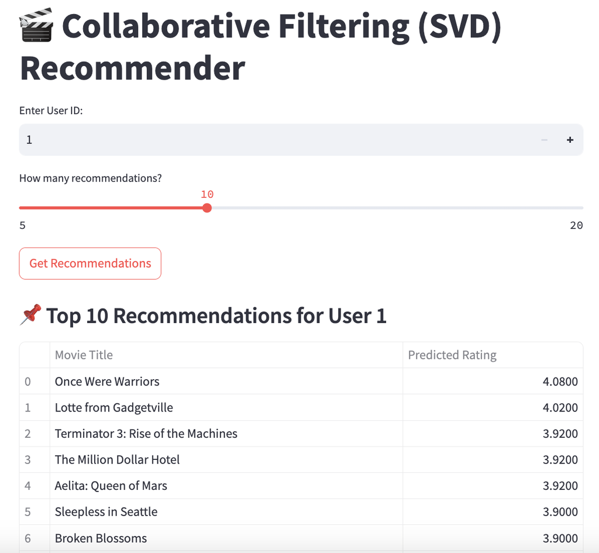

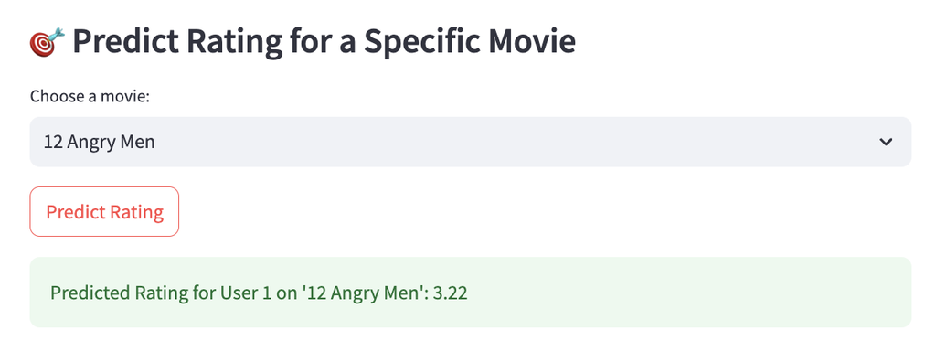

# **Movie Recommendation Webpage using Hybrid model (Streamlit UI)**

This code represents the **user interface component** of a Streamlit-based **hybrid movie recommendation system**, designed to deliver personalized movie suggestions interactively.

##### **How it works:**

1. **Select Movie Title**
   - Users interact with a searchable dropdown containing movie titles.
   - Allows easy selection of a film of interest.
2. **Enter User ID**
   - Users input their unique User ID.
   - Essential for personalizing recommendations via collaborative filtering (**SVD model**).
3. **Choose Number of Recommendations**
   - A slider enables users to select how many recommendations they wish to receive (**between 5 and 50**).
4. **Generate Recommendations**
   - Clicking the **"Recommend"** button initiates:
     - **Content-based filtering** (genre similarity).
     - **Collaborative filtering** (SVD-predicted ratings).
   - Combines both methods to create a ranked list of recommended movies.
5. **Display Results**
   - Recommendations appear in a clear table with columns:
     - **Title**
     - **Genres**
     - **Vote Average** (general audience preference)
     - **Predicted SVD Score** (personalized rating prediction)
     - **Final Hybrid Score** (average of vote average and SVD score)
6. **Handling No Recommendations**
   - If no suitable recommendations are found, a user-friendly warning message is displayed.

```python
with open("app4.py", "w") as f:
    f.write('''import streamlit as st
import pandas as pd
import numpy as np
from sklearn.feature_extraction.text import TfidfVectorizer
from sklearn.neighbors import NearestNeighbors
from surprise import Dataset, Reader, SVD

# Load cleaned data
df = pd.read_csv("cleaned_movie_ratings.csv")
df['genres'] = df['genres'].fillna('')

# --- Collaborative Filtering Setup (SVD) ---
reader = Reader(rating_scale=(0.5, 5.0))
data = Dataset.load_from_df(df[['userId', 'movieId', 'rating']], reader)
trainset = data.build_full_trainset()
svd_model = SVD()
svd_model.fit(trainset)

# --- Content-Based Filtering Setup (KNN on genres) ---
tfidf_vectorizer = TfidfVectorizer(stop_words='english')
tfidf_matrix = tfidf_vectorizer.fit_transform(df['genres'])
knn_model = NearestNeighbors(metric='cosine', algorithm='brute', n_neighbors=200)
knn_model.fit(tfidf_matrix)

# --- Mappings ---
title_to_index = pd.Series(df.index, index=df['title']).drop_duplicates()

# --- Hybrid Recommendation Function ---
def recommend_hybrid(movie_title, user_id, n=10):
    if movie_title not in title_to_index:
        return pd.DataFrame({"Error": [f"Movie '{movie_title}' not found in dataset."]})

    idx = title_to_index[movie_title]
    distances, indices = knn_model.kneighbors(tfidf_matrix[idx], n_neighbors=200)
    movie_indices = indices[0][1:]

    recommendations = df.iloc[movie_indices][["movieId", "title", "vote_average", "genres"]]
    recommendations = recommendations.drop_duplicates(subset="title")  # ensure unique titles

    # Add collaborative SVD predictions
    recommendations["svd_score"] = recommendations["movieId"].apply(lambda x: svd_model.predict(user_id, x).est)

    # Combine to hybrid score
    recommendations["hybrid_score"] = (recommendations["vote_average"] + recommendations["svd_score"]) / 2

    return recommendations.sort_values(by="hybrid_score", ascending=False).head(n)

# ------------------ Streamlit UI ------------------
st.set_page_config(page_title="🎬 Hybrid Recommender", layout="centered")
st.title("🎬 Hybrid Movie Recommendation System")
st.markdown("This system combines **Content-Based Filtering (Genres)** and **Collaborative Filtering (SVD)** to deliver personalized movie recommendations.")

# 🎞️ Search and Select Movie
movie_list = sorted(df['title'].dropna().unique())
movie_input = st.selectbox("🎞️ Search and Select a Movie:", movie_list)

# 👤 User ID Input
user_id_input = st.number_input("👤 Enter User ID:", min_value=1, step=1)

# 🔢 Number of Recommendations
top_n = st.slider("📌 Number of Recommendations:", 5, 50, 10)

# 🎯 Show Recommendations
if st.button("🎯 Recommend"):
    results = recommend_hybrid(movie_input, user_id_input, n=top_n)
    if not results.empty:
        st.success(f"✅ Top {top_n} Hybrid Recommendations for User {user_id_input} Based on '{movie_input}':")
        st.dataframe(results[["title", "genres", "vote_average", "svd_score", "hybrid_score"]])
    else:
        st.warning("⚠️ No recommendations found. Try another movie or user ID.")

''')

print("app4.py file created successfully.")
```

```python
!streamlit run app4.py
```

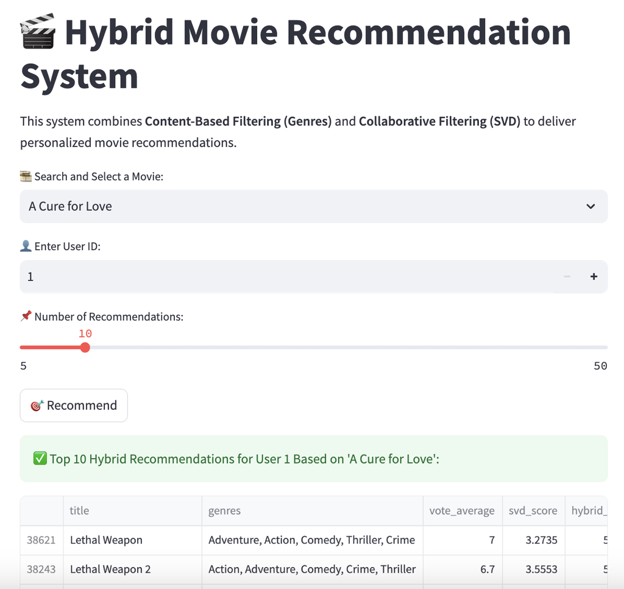

## **Coclusion**

This project explored and implemented multiple recommendation approaches—including **popularity-based**, **content-based**, **collaborative filtering (SVD)**, and **hybrid models**—using the **MovieLens dataset** enriched with movie metadata. Through extensive **exploratory data analysis (EDA)**, we gained insights into movie trends, genre popularity, rating distributions, and the relationship between budget and revenue.

The **content-based filtering** model, leveraging movie genres and **TF-IDF with KNN**, provided reasonably good recommendations based on item similarity but lacked personalization. The **collaborative filtering** model (**SVD**) outperformed others in terms of **predictive accuracy** (lowest RMSE), effectively capturing user preferences from rating patterns. However, it suffered from the **cold-start problem** for new users or items. To address this, a **hybrid model** was developed by combining content-based and collaborative approaches, resulting in improved **F1 and recall scores** and offering a better balance between personalization and generalization.

The project successfully demonstrates how integrating **metadata with user behavior** can significantly enhance recommendation quality. It also sets the foundation for future improvements, such as **deeper NLP**, **real-time updates**, **cold-start handling**, **deep learning models**, and **cross-domain recommendation** expansion.

## **Future Work**

For future work, the hybrid model can be significantly enhanced by incorporating additional metadata such as **cast**, **director**, **keywords**, and **production companies** to improve content-based filtering. Advanced Natural Language Processing (NLP) techniques like **BERT** or **word embeddings** can be used to better understand movie overviews.

To address the **cold start problem**, **demographic-based clustering** or recommending **trending/high-rated movies** can be applied for new users or items. **Real-time personalization** could also be introduced by dynamically updating recommendations based on recent user activity or implicit feedback like clicks and watch history. Moreover, evaluation strategies can be improved through **A/B testing**, **click-through rates**, or **long-term satisfaction analysis** beyond just top-N metrics.

The **Streamlit-based app** can be deployed on cloud platforms like **Heroku** or **AWS**, and enhanced with **login systems** and **interactive feedback options**. Additionally, **deep learning approaches** such as **neural collaborative filtering** or **deep hybrid models** can be explored for capturing complex user-item relationships. Finally, the system can be extended to support **cross-domain recommendations**, such as suggesting **books**, **games**, or **series** based on movie preferences to boost engagement.

## 📚 **References**

- The Movies Dataset. (2017, November 10). *Kaggle*. Retrieved from https://www.kaggle.com/datasets/rounakbanik/the-movies-dataset
- Applied AI. (n.d.). *Movie Recommendation System Using Machine Learning*. Retrieved from https://www.appliedaicourse.com/blog/movie-recommendation-system-using-machine-learning/
- Reddy, S.R.S., Nalluri, S., Kunisetti, S., Ashok, S., & Venkatesh, B. (2021). *Content-based movie recommendation system using genre correlation*. In *Materials Today: Proceedings*, 45, 7012–7015. https://doi.org/10.1016/j.matpr.2021.01.077
- Koren, Y., Bell, R., & Volinsky, C. (2009). *Matrix factorization techniques for recommender systems*. *IEEE Computer*, 42(8), 30–37. https://doi.org/10.1109/MC.2009.263
- Wang, H., Wang, N., & Yeung, D.Y. (2015). *Collaborative Deep Learning for Recommender Systems*. In *Proceedings of the 21th ACM SIGKDD International Conference on Knowledge Discovery and Data Mining (KDD '15)*, 1235–1244. https://doi.org/10.1145/2783258.2783273
- Huang, P., He, X., Gao, J., Deng, L., Acero, A., & Heck, L. (2013). *Learning Deep Structured Semantic Models for Web Search Using Clickthrough Data*. In *Proceedings of the 22nd ACM International Conference on Information & Knowledge Management (CIKM '13)*, 2333–2338. https://doi.org/10.1145/2505515.2505665
- Towards Data Science. (2019). *Building a Hybrid Recommender System – Step by Step Guide*. Retrieved from [https://towardsdatascience.com/building-a-hybrid-recommender-system-step-by-step-guide-with-movielens-dataset-8c2d5e6b3e4e]